# Homework_08.Rmd

Isaac Racine

3/10/2021

# Obtaining Data

I obtained data from [here](https://datadryad.org/stash/dataset/doi:10.5061/dryad.82vr4). The data was looking at above ground biomass of plots of forests and recorded their age. Plots age was determined by how many years it had gone undisturbed. Originally some of the data had OG (old-growth) for the plots age because it was too old to determine. However, to make things cohesive I replaced these values with 200 after seeing the other values for ages.

```r
library(ggplot2)
library(tidyverse)
library(MASS)
z <- read.table("AbovegroundData.csv",header=TRUE,sep=",", stringsAsFactors=FALSE)

#add ID column, index age and biomass to new dataframe
z <- data.frame(1:nrow(z),z$Age, z$AGB)
names(z) <- list("ID","Age","Biomass")


#change Age's with OG to 200
#OG meant they were too old to detemine an age
#we will put in age of 200
z <- z %>%
  mutate(Age = str_replace(Age, "OG", "200"))



#change age from char to int
z$Age <- as.numeric(as.character(z$Age))

#see summary
summary(z)
```

```
##        ID              Age            Biomass
##  Min.   :   1.0   Min.   :  0.00   Min.   :   0.00
##  1st Qu.: 334.2   1st Qu.: 10.00   1st Qu.:  43.41
##  Median : 667.5   Median : 20.00   Median :  98.31
##  Mean   : 667.5   Mean   : 42.65   Mean   : 141.51
##  3rd Qu.:1000.8   3rd Qu.: 40.00   3rd Qu.: 176.67
##  Max.   :1334.0   Max.   :200.00   Max.   :3655.20
```

# Data Manipulation

After reading the paper associated with the data I decided to group the ages into young (20 years and younger), middle (21-199 years) and old (200 or OG) plots. This allowed for a hypothesis to be formulated.

```
If a plot is older in the years it has gone undistrubed then the plot should have a larger quantity of biomass because there has been more time for undistrubed growth.
```

```r
#Can group ages into treatments
#0-20 is young
#21-199 is middle
#200+ is old
z <- split(z, cut(z$Age, c(0,20,199,200), include.lowest = TRUE))
```

# Getting parameters for normal distribution

Now that the data was groupped accordingly the number of trials, mean and variance for each treatment could be calculated. These values were then used to simulate data for each treatment and regroupped into one dataframe. However, upon running the ANOVA analysis there was seemingly no way that the simulated data could make a significant result. Thus, to make the data ideal for the remainder of this assignment the variance was reduced somewhat proportionally to the variance of each group. This allowed for the simulated data to be useable.

```r
#Now that they're split here are their summary stats
#Group Young
young_num <- length(z$`[0,20]`$Biomass)
young_mean <- mean(z$`[0,20]`$Biomass)
young_var <- var(z$`[0,20]`$Biomass)/20

#Group Middle
middle_num <- length(z$`(20,199]`$Biomass)
middle_mean <- mean(z$`(20,199]`$Biomass)
middle_var <- var(z$`(20,199]`$Biomass)/90

#Group Old
old_num <- length(z$`(199,200]`$Biomass)
old_mean <- mean(z$`(199,200]`$Biomass)
old_var <- var(z$`(199,200]`$Biomass)/100

#The variation of the groups were very large. To make the data actually significantly different I had to lessen the variation.
#-------------- Creating Simulated (Radnom) Data --------------
#First run the number of simulated data points needed
#for each treatment group
young_data <- rnorm(young_num, young_mean, young_var)

middle_data <- rnorm(middle_num, middle_mean, middle_var)

old_data <- rnorm(old_num, old_mean, old_var)

#combine the treatment randomly generated biomass
#into one vector
vec_biomass <- c(young_data, middle_data, old_data)

#make vector to hold the treatment name
vec_treatment <- c(rep("Young", young_num), rep("Middle", middle_num), rep("Old", old_num))

#Create the data frame and give it names
rand_data <- data.frame(1:(young_num+middle_num+old_num),
                        vec_treatment, vec_biomass)
names(rand_data) <- list("ID", "Treatment", "Biomass")
head(rand_data)
```

```
##   ID Treatment    Biomass
## 1  1     Young  658.18118
## 2  2     Young -418.78983
## 3  3     Young  -76.19161
## 4  4     Young   62.99492
## 5  5     Young  357.64898
## 6  6     Young  506.72828
```

# First ANOVA Test (Question 4)

The data was manipulated so that the simulated data would always make a significant output. Here are the results and a plot of the ANOVA.

```r
#-------------- Make Model and PLot ---------------
#Here we will make an ANOVA test and plot
ANOmodel <- aov(Biomass~Treatment,data=rand_data)
print(summary(ANOmodel))
```

```
##               Df    Sum Sq Mean Sq F value   Pr(>F)
## Treatment      2   7923002 3961501   14.31 7.08e-07 ***
## Residuals   1331 368385440  276773
## ---
## Signif. codes:  0 '***' 0.001 '**' 0.01 '*' 0.05 '.' 0.1 ' ' 1
```

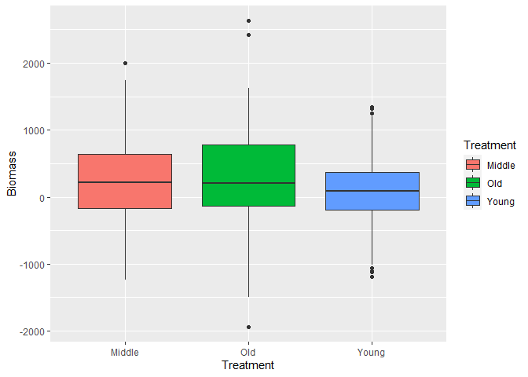

```r
ANOplot <- ggplot(data=rand_data, aes(x=Treatment, y=Biomass,
                                      fill = Treatment)) +
  geom_boxplot()
print(ANOplot)
```

# Adjusting Means to Test Effect Size (Question 5)

In an attempt to reduce the effect size to the smallest value possible while also maintaining significant results I tried changing the means of some treatments. Since the middle group had mean about 100 units above the young and 100 units below the old it seemed best to set the young and old mean values to the middle and work from there. After testing several values it seems that the smallest effect size was 140, or there was a difference of 140 between means of different groups. However, compared to the effect size of 200 that was given with the original data this effect size has reduced greatly. The means would be more reducible if the data was being simulated with a gamma distribution, given that biomass can’t be below 0. Luckily, the large sample sizes of the groups allowed for even some recognizable changes in the means to still produce significant results.

```r
young_data1 <- rnorm(young_num, middle_mean-70, young_var)
middle_data1 <- rnorm(middle_num, middle_mean, middle_var)
old_data1 <- rnorm(old_num, middle_mean+70, old_var)

#combine the treatment randomly generated biomass
#into one vector
vec_biomass1 <- c(young_data1, middle_data1, old_data1)

#Create the data frame and give it names
rand_data1 <- data.frame(1:(young_num+middle_num+old_num),
                        vec_treatment, vec_biomass1)
names(rand_data1) <- list("ID", "Treatment", "Biomass")

#Here we will make an ANOVA test and plot
ANOmodel <- aov(Biomass~Treatment,data=rand_data1)
print(summary(ANOmodel))
```

```
##               Df    Sum Sq Mean Sq F value  Pr(>F)
## Treatment      2   3133209 1566605    6.22 0.00205 **
## Residuals   1331 335206313  251845
## ---
## Signif. codes:  0 '***' 0.001 '**' 0.01 '*' 0.05 '.' 0.1 ' ' 1
```

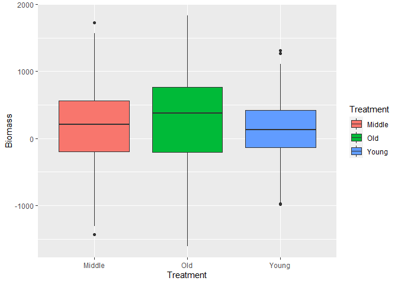

```r
ANOplot <- ggplot(data=rand_data1, aes(x=Treatment, y=Biomass,
                                      fill = Treatment)) +
  geom_boxplot()
print(ANOplot)
```

# Adjusting Sample Size (Question 7)

```r
#-------------- Testing Sample Size ---------------
#try to simulate data with smaller to see the minimum sample size needed to still have significant results
young_data2 <- rnorm(ceiling(young_num/2.7), young_mean, young_var)
middle_data2 <- rnorm(ceiling(middle_num/2.7), middle_mean, middle_var)
old_data2 <- rnorm(ceiling(old_num/2.7), old_mean, old_var)

#combine the treatment randomly generated biomass
#into one vector
vec_biomass2 <- c(young_data2, middle_data2, old_data2)
vec_treatment2 <- c(rep("Young", ceiling(young_num/2.7)), rep("Middle", ceiling(middle_num/2.7)), rep("Old", ceiling(old_num/2.7)))

#Create the data frame and give it names
rand_data2 <- data.frame(1:(ceiling(young_num/2.7)+ceiling(middle_num/2.7)+ceiling(old_num/2.7)),
                         vec_treatment2, vec_biomass2)
names(rand_data2) <- list("ID", "Treatment", "Biomass")

#Here we will make an ANOVA test and plot
ANOmodel <- aov(Biomass~Treatment,data=rand_data2)
print(summary(ANOmodel))
```

```
##              Df    Sum Sq Mean Sq F value Pr(>F)
## Treatment     2    961786  480893   1.879  0.154
## Residuals   492 125932129  255960
```

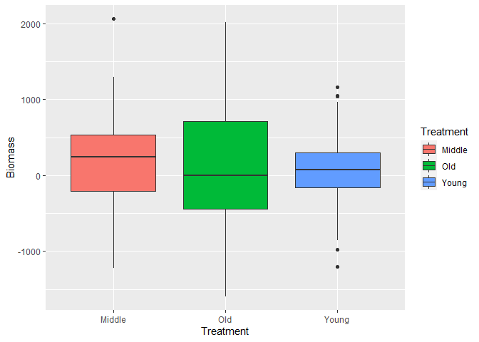

```r
ANOplot <- ggplot(data=rand_data2, aes(x=Treatment, y=Biomass,
                                       fill = Treatment)) +
  geom_boxplot()
print(ANOplot)
```

# Question 9 -> Using Gamma instead of Normal

This part asked to simmulate the data with a more complex distribution. This worked heavily in my favor. Gamma disributions can’t be less than 0 which is applicable to biomass as nothing can weight 0 or less. Thus I redid all of parts above just with the gamma distribution. Since I was using gamma to simulate data the variances didn’t have to be manipulated to make the simulated data significant.

```r
z <- read.table("AbovegroundData.csv",header=TRUE,sep=",", stringsAsFactors=FALSE)

#add ID column, index age and biomass to new dataframe
z <- data.frame(1:nrow(z),z$Age, z$AGB)
names(z) <- list("ID","Age","Biomass")


#change Age's with OG to 200
#OG meant they were too old to detemine an age
#we will put in age of 200
z <- z %>%
  mutate(Age = str_replace(Age, "OG", "200"))



#change age from char to int
z$Age <- as.numeric(as.character(z$Age))

#see summary
summary(z)
```

```
##        ID              Age            Biomass
##  Min.   :   1.0   Min.   :  0.00   Min.   :   0.00
##  1st Qu.: 334.2   1st Qu.: 10.00   1st Qu.:  43.41
##  Median : 667.5   Median : 20.00   Median :  98.31
##  Mean   : 667.5   Mean   : 42.65   Mean   : 141.51
##  3rd Qu.:1000.8   3rd Qu.: 40.00   3rd Qu.: 176.67
##  Max.   :1334.0   Max.   :200.00   Max.   :3655.20
```

```r
#Can group ages into treatments
#0-20 is young
#21-199 is middle
#200+ is old
z <- split(z, cut(z$Age, c(0,20,199,200), include.lowest = TRUE))

#Now that they're split here are their summary stats
#Group Young
young_num <- length(z$`[0,20]`$Biomass)
young_mean <- mean(z$`[0,20]`$Biomass)
young_var <- var(z$`[0,20]`$Biomass)

#Group Middle
middle_num <- length(z$`(20,199]`$Biomass)
middle_mean <- mean(z$`(20,199]`$Biomass)
middle_var <- var(z$`(20,199]`$Biomass)

#Group Old
old_num <- length(z$`(199,200]`$Biomass)
old_mean <- mean(z$`(199,200]`$Biomass)
old_var <- var(z$`(199,200]`$Biomass)
```

## Parameter Calculations

However, since gamma uses parameters called shape and scale I had to calculate those from each groups mean and variance. Then the data could be simulated for each treatment age.

> mean = shape * scale

> variance = shape * scale<sup>2</sup>

```r
young_shape <- (young_mean^2)/young_var
young_scale <- young_var/young_mean
young_data <- rgamma(young_num, shape = young_shape,
                     scale = young_scale)

middle_shape <- (middle_mean^2)/middle_var
middle_scale <- middle_var/middle_mean
middle_data <- rgamma(middle_num, shape = middle_shape,
                     scale = middle_scale)


old_shape <- (old_mean^2)/old_var
old_scale <- old_var/old_mean
old_data <- rgamma(old_num, shape = old_shape,
                     scale = old_scale)
```

## Dataframe construction

With the newly simulated data another data frame needed to be constructed.

```r
#combine the treatment randomly generated biomass
#into one vector
vec_biomass <- c(young_data, middle_data, old_data)

#make vector to hold the treatment name
vec_treatment <- c(rep("Young", young_num), rep("Middle", middle_num), rep("Old", old_num))

#Create the data frame and give it names
rand_data <- data.frame(1:(young_num+middle_num+old_num),
                        vec_treatment, vec_biomass)
names(rand_data) <- list("ID", "Treatment", "Biomass")
head(rand_data)
```

```
##   ID Treatment   Biomass
## 1  1     Young 112.02138
## 2  2     Young 166.58481
## 3  3     Young  36.31815
## 4  4     Young  97.18643
## 5  5     Young 121.38167
## 6  6     Young  36.99659
```

## ANOVA Test and Plot

Now an ANOVA test could be run and plotted for the data.

```r
#Here we will make an ANOVA test and plot
ANOmodel <- aov(Biomass~Treatment,data=rand_data)
print(summary(ANOmodel))
```

```
##               Df   Sum Sq Mean Sq F value Pr(>F)
## Treatment      2  6187340 3093670   107.8 <2e-16 ***
## Residuals   1331 38189356   28692
## ---
## Signif. codes:  0 '***' 0.001 '**' 0.01 '*' 0.05 '.' 0.1 ' ' 1
```

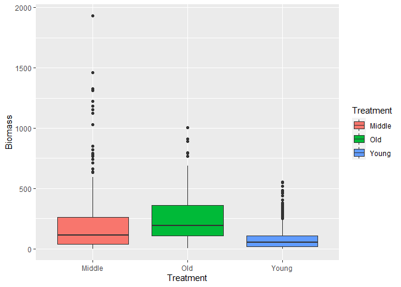

```r
ANOplot <- ggplot(data=rand_data, aes(x=Treatment, y=Biomass,
                                      fill = Treatment)) +
  geom_boxplot()
print(ANOplot)
```

## Adjusting Means

Here the effective size is very small! Although the different groups do not all have the same mean, the treatments do in fact all have the same shape! Shape is related to mean and variance, so the fact that each treatment group could have the same shape and still get significant reults meant that the difference between the means were pretty small.

```r
#try to simulate data with same mean
young_data1 <- rgamma(young_num, middle_shape, young_scale)
middle_data1 <- rgamma(middle_num, middle_shape, middle_scale)
old_data1 <- rgamma(old_num, middle_shape, old_scale)

#combine the treatment randomly generated biomass
#into one vector
vec_biomass1 <- c(young_data1, middle_data1, old_data1)

#Create the data frame and give it names
rand_data1 <- data.frame(1:(young_num+middle_num+old_num),
                         vec_treatment, vec_biomass1)
names(rand_data1) <- list("ID", "Treatment", "Biomass")

#Here we will make an ANOVA test and plot
ANOmodel <- aov(Biomass~Treatment,data=rand_data1)
print(summary(ANOmodel))
```

```
##               Df  Sum Sq  Mean Sq F value Pr(>F)
## Treatment      2 0.00795 0.003975   89.19 <2e-16 ***
## Residuals   1331 0.05931 0.000045
## ---
## Signif. codes:  0 '***' 0.001 '**' 0.01 '*' 0.05 '.' 0.1 ' ' 1
```

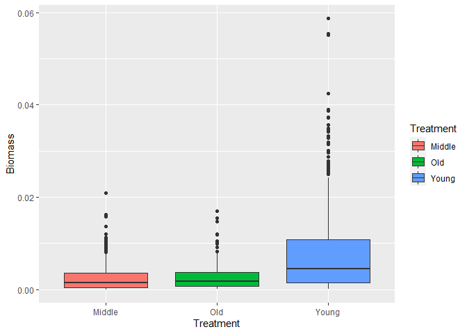

```r
ANOplot <- ggplot(data=rand_data1, aes(x=Treatment, y=Biomass,
                                       fill = Treatment)) +
  geom_boxplot()
print(ANOplot)
```

## Adjusting Sample Sizes

```r
#try to simulate data with smaller sample sizes to see the minimum sample size needed to still have significant results
young_data2 <- rgamma(ceiling(young_num/19), young_shape, young_scale)
middle_data2 <- rgamma(ceiling(middle_num/19), middle_shape, middle_scale)
old_data2 <- rgamma(ceiling(old_num/19), old_shape, old_scale)

#combine the treatment randomly generated biomass
#into one vector
vec_biomass2 <- c(young_data2, middle_data2, old_data2)
vec_treatment2 <- c(rep("Young", ceiling(young_num/19)), rep("Middle", ceiling(middle_num/19)), rep("Old", ceiling(old_num/19)))

#Create the data frame and give it names
rand_data2 <- data.frame(1:length(vec_treatment2),
                         vec_treatment2, vec_biomass2)
names(rand_data2) <- list("ID", "Treatment", "Biomass")

#Here we will make an ANOVA test and plot
ANOmodel <- aov(Biomass~Treatment,data=rand_data2)
print(summary(ANOmodel))
```

```
##             Df    Sum Sq  Mean Sq F value Pr(>F)
## Treatment    2 0.0004019 2.01e-04   5.726  0.005 **
## Residuals   69 0.0024219 3.51e-05
## ---
## Signif. codes:  0 '***' 0.001 '**' 0.01 '*' 0.05 '.' 0.1 ' ' 1
```

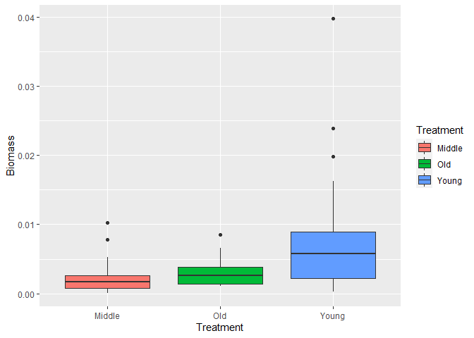

```r
ANOplot <- ggplot(data=rand_data2, aes(x=Treatment, y=Biomass,
                                       fill = Treatment)) +
  geom_boxplot()
print(ANOplot)
```

All of the values for smallest meand and smallest sample size were run several times to see if it could consistently produce results with p-values less than 0.05. However, with any simulate data there were some cases that the p-value was not significant. However, overall the changed data seemed to produce significant results.

Homepage